# TÜİK Forecasting Project: Non-Domestic Producer Price Index

Mehmet Zahid Kemik (138722034)

2026-05-31

# 1 Project Overview

This project forecasts the next monthly observation of the **Non-Domestic Producer Price Index (2010=100)** published by TÜİK. This index tracks import prices in Türkiye and is closely related to exchange-rate pass-through and inflation dynamics.

The analysis uses the `tuikr` package to access TÜİK data. When the SDMX endpoint returns an authorization error, the notebook automatically falls back to the official TÜİK portal table path documented in the `tuikr` package.

# 2 Data Source and TÜİK Connection

```r
project_data <- load_project_series(lang = "en")
raw_data <- project_data$raw_data
series_tbl <- project_data$series
target_info <- project_data$target
access_date <- project_data$access_date
meta <- project_data$meta

knitr::kable(data.frame(
  Field = c(
    "TÜİK data set name",
    "TÜİK theme / category",
    "TÜİK table name",
    "tuikr dataflow ID",
    "Selected variable",
    "Data frequency",
    "Time coverage",
    "Latest available observation",
    "Forecast target period",
    "Date of data access",
    "Data access method"
  ),
  Value = c(
    meta$dataset_name,
    meta$theme,
    meta$table_name,
    meta$dataflow_id,
    meta$selected_variable,
    meta$frequency,
    paste(format_period_label(min(series_tbl$period_date)), "to", format_period_label(max(series_tbl$period_date))),
    target_info$latest_observation,
    target_info$forecast_target_period,
    as.character(access_date),
    project_data$access_method
  )
))
```

| Field | Value |
| --- | --- |
| TÜİK data set name | Non-Domestic Producer Price Index and Rate of Change [2010=100] |
| TÜİK theme / category | Price Statistics |
| TÜİK table name | Non-Domestic Producer Price Index and Rate of Change [2010=100] |
| tuikr dataflow ID | TR,DF_YDUFE_EDO_V1,1.0 |
| Selected variable | Non-Domestic Producer Price Index (2010=100) |
| Data frequency | Monthly |
| Time coverage | 2010-01 to 2026-02 |
| Latest available observation | 2026-02 |
| Forecast target period | 2026-03 |
| Date of data access | 2026-05-31 |
| Data access method | portal_istab |

The data were accessed through the `tuikr` package. The notebook first attempts `tuikr::statistical_data()` using the registered SDMX dataflow ID. If the SDMX service returns an authorization error, it uses `tuikr::statistical_tables()` to locate the official TÜİK portal table and downloads that table programmatically inside R without saving a separate data file to the repository.

Package source: https://github.com/emraher/tuikr

```r
knitr::kable(head(raw_data, 10))
```

| INDICATOR | INDICATOR_label | obsTime | obsValue |
| --- | --- | --- | --- |
| NON_DOMESTIC_PPI | Non-Domestic Producer Price Index (2010=100) | 2010-01 | 97.88 |
| NON_DOMESTIC_PPI | Non-Domestic Producer Price Index (2010=100) | 2010-02 | 98.07 |
| NON_DOMESTIC_PPI | Non-Domestic Producer Price Index (2010=100) | 2010-03 | 99.98 |
| NON_DOMESTIC_PPI | Non-Domestic Producer Price Index (2010=100) | 2010-04 | 100.64 |
| NON_DOMESTIC_PPI | Non-Domestic Producer Price Index (2010=100) | 2010-05 | 100.20 |
| NON_DOMESTIC_PPI | Non-Domestic Producer Price Index (2010=100) | 2010-06 | 99.49 |
| NON_DOMESTIC_PPI | Non-Domestic Producer Price Index (2010=100) | 2010-07 | 99.45 |
| NON_DOMESTIC_PPI | Non-Domestic Producer Price Index (2010=100) | 2010-08 | 99.67 |
| NON_DOMESTIC_PPI | Non-Domestic Producer Price Index (2010=100) | 2010-09 | 100.24 |
| NON_DOMESTIC_PPI | Non-Domestic Producer Price Index (2010=100) | 2010-10 | 100.12 |

# 3 Use of TÜİK Data in R

After importing the TÜİK table through `tuikr`, the notebook keeps only the **national monthly non-domestic producer price index level**. Rate-of-change indicators and disaggregated sub-indices are excluded so that the selected variable remains a single numeric time series suitable for forecasting.

The main adjustments performed in R are:

1. Selecting the non-domestic producer price index variable rather than monthly or annual change rates.
2. Using `obsTime` as the period variable and converting it to monthly dates.
3. Sorting observations chronologically and removing duplicate periods.
4. Confirming that `obsValue` is numeric and checking for missing observations.

```r
cat("Number of observations:", nrow(series_tbl), "\n")
```

```
## Number of observations: 194
```

```r
cat("First period:", format_period_label(min(series_tbl$period_date)), "\n")
```

```
## First period: 2010-01
```

```r
cat("Last period:", format_period_label(max(series_tbl$period_date)), "\n")
```

```
## Last period: 2026-02
```

```r
cat("Any missing values:", any(is.na(series_tbl$value)), "\n")
```

```
## Any missing values: FALSE
```

# 4 Exploratory Time Series Analysis

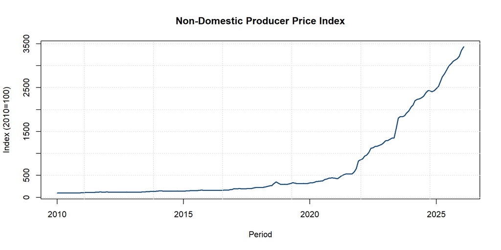

Actual monthly Non-Domestic Producer Price Index.

```r
plot(
  series_tbl$period_date,
  series_tbl$value,
  type = "l",
  lwd = 2,
  col = "#1f4e79",
  xlab = "Period",
  ylab = "Index (2010=100)",
  main = "Non-Domestic Producer Price Index"
)
grid()
```

**Trend:** The series shows a strong upward trend, especially in recent years, which reflects imported inflation pressure in Türkiye.

**Random variation:** Short-term fluctuations remain around the trend, indicating that no method fits perfectly without error.

**Missing values / outliers:** The prepared series does not contain missing monthly periods in the filtered national index series. Extreme increases during high-inflation periods are economically meaningful rather than data errors.

# 5 Forecasting Methods Applied

The following sections apply all required forecasting methods. Accuracy is evaluated on in-sample fitted or one-step-ahead values, while the next-period forecast uses the full sample.

## 5.1 7.1 Naïve Forecasting

```r
method_results <- run_all_forecasting_methods(series_tbl)
naive_result <- method_results$naive
tail(data.frame(actual = naive_result$actual, forecast = naive_result$forecast), 5)
```

|  | actual | forecast |
| --- | --- | --- |
| 189 | 3128.21 | 3100.35 |
| 190 | 3160.27 | 3128.21 |
| 191 | 3219.70 | 3160.27 |
| 192 | 3350.38 | 3219.70 |
| 193 | 3429.99 | 3350.38 |

```r
calc_accuracy_measures(naive_result$actual, naive_result$forecast)
```

| bias | mad | mse | mape | rsfe | tracking_signal |
| --- | --- | --- | --- | --- | --- |
| 17.26482 | 19.20927 | 1567.677 | 2.452153 | 3332.11 | 173.4636 |

**Interpretation:** The naïve method assumes that the next value equals the most recent observation. It is simple, but it ignores trend and seasonality.

## 5.2 7.2 Moving Average

A **3-month window** is used because producer price inflation reacts quickly to recent shocks, while a longer window would over-smooth short-run dynamics.

```r
ma_result <- method_results$moving_average
calc_accuracy_measures(ma_result$actual, ma_result$forecast)
```

| bias | mad | mse | mape | rsfe | tracking_signal |
| --- | --- | --- | --- | --- | --- |
| 34.23468 | 36.00393 | 4747.231 | 4.196233 | 6538.823 | 181.6142 |

## 5.3 7.3 Weighted Moving Average

```r
wma_result <- method_results$weighted_moving_average
wma_result$weights
```

```
## [1] 0.5 0.3 0.2
```

```r
calc_accuracy_measures(wma_result$actual, wma_result$forecast)
```

| bias | mad | mse | mape | rsfe | tracking_signal |
| --- | --- | --- | --- | --- | --- |
| 39.22915 | 41.18064 | 6116.954 | 4.775589 | 7492.768 | 181.9488 |

## 5.4 7.4 Exponential Smoothing

The smoothing parameter **alpha = 0.30** balances responsiveness and stability for a volatile monthly inflation-related index.

```r
es_result <- method_results$exponential_smoothing
calc_accuracy_measures(es_result$actual, es_result$forecast)
```

| bias | mad | mse | mape | rsfe | tracking_signal |
| --- | --- | --- | --- | --- | --- |
| 54.46363 | 55.0214 | 9818.669 | 5.729509 | 10511.48 | 191.0435 |

## 5.5 7.5 Trend-Adjusted Exponential Smoothing

The series displays a meaningful upward trend, so Holt-style smoothing is applicable with **alpha = 0.30** and **beta = 0.20**.

```r
holt_result <- method_results$trend_adjusted_smoothing
calc_accuracy_measures(holt_result$actual, holt_result$forecast)
```

| bias | mad | mse | mape | rsfe | tracking_signal |
| --- | --- | --- | --- | --- | --- |
| -11.59331 | 21.66262 | 1508.649 | 2.702965 | -2237.509 | -103.289 |

**Interpretation:** This method captures both level and trend, which is important for a producer price index under persistent inflation.

## 5.6 7.6 Linear Trend Projection

```r
lt_result <- method_results$linear_trend
lt_result$equation
```

```
## [1] "y = -555.8425 + 12.7331 * t"
```

```r
summary(lt_result$model)
```

```
##
## Call:
## lm(formula = y ~ t_index)
##
## Residuals:
##    Min     1Q Median     3Q    Max
## -725.4 -434.1 -114.5  384.3 1515.6
##
## Coefficients:
##              Estimate Std. Error t value Pr(>|t|)
## (Intercept) -555.8425    76.2001  -7.295 7.67e-12 ***
## t_index       12.7331     0.6777  18.789  < 2e-16 ***
## ---
## Signif. codes:  0 '***' 0.001 '**' 0.01 '*' 0.05 '.' 0.1 ' ' 1
##
## Residual standard error: 528.6 on 192 degrees of freedom
## Multiple R-squared:  0.6477, Adjusted R-squared:  0.6459
## F-statistic:   353 on 1 and 192 DF,  p-value: < 2.2e-16
```

```r
calc_accuracy_measures(lt_result$actual, lt_result$forecast)
```

| bias | mad | mse | mape | rsfe | tracking_signal |
| --- | --- | --- | --- | --- | --- |
| -1.887036e-14 | 442.0696 | 276560.2 | 159.0508 | -3.680611e-12 | -8.325864e-15 |

**Interpretation of intercept:** The intercept represents the estimated index level at the beginning of the sample period after accounting for the linear time trend.

**Interpretation of slope:** The positive slope indicates that the total producer price index increases over time on average.

## 5.7 7.7 Seasonal Indices

Monthly data support a 12-season structure.

```r
si_result <- method_results$seasonal_indices
round(si_result$seasonal_index, 3)
```

```
##     1     2     3     4     5     6     7     8     9    10    11    12
## 1.003 0.989 0.996 0.996 0.997 1.003 1.001 1.010 1.012 1.002 0.992 1.000
```

```r
calc_accuracy_measures(si_result$actual, si_result$forecast)
```

| bias | mad | mse | mape | rsfe | tracking_signal |
| --- | --- | --- | --- | --- | --- |
| -9.941312 | 17.91617 | 1267.556 | 3.013801 | -1819.26 | -101.5429 |

**Interpretation:** Months with seasonal indices above 1.00 tend to have relatively higher producer price index levels after removing trend effects.

## 5.8 7.8 Additive Decomposition

```r
add_result <- method_results$additive_decomposition
calc_accuracy_measures(add_result$actual, add_result$forecast)
```

| bias | mad | mse | mape | rsfe | tracking_signal |
| --- | --- | --- | --- | --- | --- |
| -2.028099 | 19.02805 | 1070.621 | 4.588919 | -369.114 | -19.39841 |

**Interpretation:** Additive decomposition separates trend, seasonal, and random components. It is suitable because seasonal swings are roughly stable relative to the level of the series.

## 5.9 7.9 Multiplicative Decomposition

```r
mult_result <- method_results$multiplicative_decomposition
calc_accuracy_measures(mult_result$actual, mult_result$forecast)
```

| bias | mad | mse | mape | rsfe | tracking_signal |
| --- | --- | --- | --- | --- | --- |
| -1.905085 | 16.22266 | 1035.652 | 2.706017 | -346.7255 | -21.37291 |

**Interpretation:** Multiplicative decomposition is also applicable because all index values are positive and seasonal effects can widen as the series level rises.

## 5.10 7.10 Regression with Trend and Seasonal Dummy Variables

```r
reg_result <- method_results$regression_seasonal
summary(reg_result$model)
```

```
##
## Call:
## lm(formula = y ~ t_index + month_factor)
##
## Residuals:
##    Min     1Q Median     3Q    Max
## -774.6 -445.5 -104.9  386.5 1466.9
##
## Coefficients:
##                 Estimate Std. Error t value Pr(>|t|)
## (Intercept)    -504.4186   148.2456  -3.403 0.000822 ***
## t_index          12.7247     0.6979  18.233  < 2e-16 ***
## month_factor02   -1.0747   186.5166  -0.006 0.995409
## month_factor03  -83.3536   189.4277  -0.440 0.660441
## month_factor04  -78.8764   189.4187  -0.416 0.677601
## month_factor05  -78.6955   189.4123  -0.415 0.678289
## month_factor06  -63.1620   189.4085  -0.333 0.739166
## month_factor07  -51.5742   189.4072  -0.272 0.785707
## month_factor08  -48.1663   189.4085  -0.254 0.799554
## month_factor09  -49.4554   189.4123  -0.261 0.794313
## month_factor10  -54.6381   189.4187  -0.288 0.773331
## month_factor11  -56.7059   189.4277  -0.299 0.765014
## month_factor12  -47.8187   189.4393  -0.252 0.801001
## ---
## Signif. codes:  0 '***' 0.001 '**' 0.01 '*' 0.05 '.' 0.1 ' ' 1
##
## Residual standard error: 543.8 on 181 degrees of freedom
## Multiple R-squared:  0.6486, Adjusted R-squared:  0.6253
## F-statistic: 27.84 on 12 and 181 DF,  p-value: < 2.2e-16
```

```r
calc_accuracy_measures(reg_result$actual, reg_result$forecast)
```

| bias | mad | mse | mape | rsfe | tracking_signal |
| --- | --- | --- | --- | --- | --- |
| 5.733215e-14 | 441.5211 | 275882.8 | 158.9858 | 1.108447e-11 | 2.510518e-14 |

**Interpretation:** The trend coefficient shows the average monthly change in the index, while seasonal dummy variables capture systematic month-specific deviations from trend.

# 6 Forecast Accuracy Comparison

```r
next_forecasts <- extract_next_forecasts(method_results, series_tbl)
comparison_tbl <- make_comparison_table(method_results, next_forecasts)
knitr::kable(comparison_tbl, digits = 4)
```

| method_key | method | bias | mad | mse | mape | rsfe | tracking_signal | next_period_forecast | status |
| --- | --- | --- | --- | --- | --- | --- | --- | --- | --- |
| naive | Naive Forecasting | 17.2648 | 19.2093 | 1567.677 | 2.4522 | 3332.1100 | 173.4636 | 3429.990 | Applied |
| moving_average | Moving Average | 34.2347 | 36.0039 | 4747.231 | 4.1962 | 6538.8233 | 181.6142 | 3333.357 | Applied |
| weighted_moving_average | Weighted Moving Average | 39.2292 | 41.1806 | 6116.954 | 4.7756 | 7492.7680 | 181.9488 | 3300.962 | Applied |
| exponential_smoothing | Exponential Smoothing | 54.4636 | 55.0214 | 9818.669 | 5.7295 | 10511.4807 | 191.0435 | 3251.324 | Applied |
| trend_adjusted_smoothing | Trend-Adjusted Exponential Smoothing | -11.5933 | 21.6626 | 1508.649 | 2.7030 | -2237.5091 | -103.2890 | 3467.966 | Applied |
| linear_trend | Linear Trend Projection | 0.0000 | 442.0696 | 276560.167 | 159.0508 | 0.0000 | 0.0000 | 1927.104 | Applied |
| seasonal_indices | Seasonal Indices | -9.9413 | 17.9162 | 1267.556 | 3.0138 | -1819.2600 | -101.5429 | 2683.227 | Applied |
| additive_decomposition | Additive Decomposition | -2.0281 | 19.0280 | 1070.621 | 4.5889 | -369.1140 | -19.3984 | 3002.722 | Applied |
| multiplicative_decomposition | Multiplicative Decomposition | -1.9051 | 16.2227 | 1035.652 | 2.7060 | -346.7255 | -21.3729 | 2994.103 | Applied |
| regression_seasonal | Regression with Trend and Seasonal Dummies | 0.0000 | 441.5211 | 275882.824 | 158.9858 | 0.0000 | 0.0000 | 1893.537 | Applied |

```r
write.csv(comparison_tbl, "outputs/tables/accuracy_comparison.csv", row.names = FALSE)
```

# 7 Actual vs Forecast Plots

```r
par(mfrow = c(2, 2), mar = c(4, 4, 3, 1))
for (res in list(naive_result, ma_result, holt_result, reg_result)) {
  plot_actual_vs_forecast(
    series_tbl = series_tbl,
    method_result = res,
    save_path = tempfile(),
    title = res$method
  )
}
par(mfrow = c(1, 1))
```

[output not shown]

# 8 Selection of the Superior Method

```r
superior <- select_superior_method(comparison_tbl, method_results)
superior$method
```

```
## [1] "Multiplicative Decomposition"
```

```r
superior$reason
```

```
## [1] "Multiplicative Decomposition combines competitive accuracy with a structure that matches the monthly trend and seasonality observed in the Non-Domestic Producer Price Index series."
```

The superior method is selected using both numerical accuracy and suitability to the data structure. A method with the lowest MAD is preferred only if it also matches the observed monthly trend and seasonality of the producer price index.

# 9 Final Next-Period Forecast

```r
final_method_name <- superior$method
final_key <- superior$method_key
final_result <- method_results[[final_key]]
final_forecast_value <- next_forecasts[[final_key]]

final_tbl <- data.frame(
  selected_superior_method = final_method_name,
  date_of_data_access = as.character(access_date),
  latest_available_observation = target_info$latest_observation,
  forecast_target_period = target_info$forecast_target_period,
  forecasted_value = round(final_forecast_value, 4),
  mad = comparison_tbl$mad[comparison_tbl$method_key == final_key],
  mape = comparison_tbl$mape[comparison_tbl$method_key == final_key]
)

knitr::kable(final_tbl, digits = 4)
```

| selected_superior_method | date_of_data_access | latest_available_observation | forecast_target_period | forecasted_value | mad | mape |
| --- | --- | --- | --- | --- | --- | --- |
| Multiplicative Decomposition | 2026-05-31 | 2026-02 | 2026-03 | 2994.103 | 16.2227 | 2.706 |

```r
write.csv(final_tbl, "outputs/tables/final_forecast.csv", row.names = FALSE)

plot_superior_method(
  series_tbl = series_tbl,
  method_result = final_result,
  next_forecast = final_forecast_value,
  target_period = target_info$forecast_target_period
)
```

[output not shown]

# 10 Limitations

- The series is affected by exchange-rate pass-through, energy prices, and policy shocks that simple forecasting methods do not model explicitly.
- TÜİK may revise previously published index values.
- Structural breaks during high-inflation periods reduce the stability of historical patterns.
- The project uses only the index level series and does not include explanatory macroeconomic variables.

# 11 Reproducibility Notes

1. Clone the public GitHub repository.
2. Open `forecasting_project.Rmd` in RStudio.
3. Install required packages if prompted in the setup chunk.
4. Knit the notebook to regenerate tables, figures, and the HTML report.
5. All TÜİK data are downloaded live through `tuikr`; no manually prepared data files are used.

# 12 Author

- **Name:** Mehmet Zahid Kemik
- **Student Number:** 138722034
- **Course:** Quantitative Analysis